# AAUP salaries analysis

Author

Regina

Published

September 1, 2024

# Preliminaries

```r
library(tidyverse)
library(readxl)
library(ggthemes)
library(scales)
library(shades)
library(ggstats)
library(labelled)
library(showtext)
library(directlabels)
library(hrbrthemes)
library(ggbeeswarm)
library(ggtext)
library(gganimate)
library(ggrepel)
```

Read in sheets separately with `readxl` package

```r
sal_data <- "2023_GU-AAUP_1_salaries.xlsx"

sal_summary <- read_xlsx(sal_data, sheet = "Summary")
sal_dc <- read_xlsx(sal_data, sheet = "DC Area Institutions")
sal_gu <- read_xlsx(sal_data, sheet = "Gallaudet University")
```

## colors

```r
# AAUP_RED  = be0b40
# GU_NAVY   = 213a5e
# GU_BLUE   = 0f4d81
# GU_BUFF   =  efca77
# GU_CREAM  =  edebeb
# GREEN         = 008f00
# AFT_BLUE  = 3C7DC0

aaup_colors = c("#be0b40","#213a5e", "#0f4d81", "#efca77", "#edebeb", "#008f00",  "#3c7dc0")

aaup_red = "#be0b40"
gu_navy = "#213a5e"
gu_blue = "#0f4d81"
gu_buff = "#efca77"
gu_cream = "#edebeb"
aaup_green = "#008f00"
aft_blue = "#3c7dc0"

fac_admin_colors <- c(aaup_green, aaup_red) # for comparing admin to faculty, set admin color first
```

Set a good background color for the text boxes

```r
# swatch(gradient(c(gu_buff, gu_cream),4))

bg_mid <- gradient(c(gu_buff, gu_cream),4)[3]
```

## data wrangling

Create object with local universities

```r
sal_local <- bind_rows(sal_dc, sal_gu)
```

Put specific university details here

```r
univ_id <- 131450
univ_name <- "Gallaudet University"
univ_name_short <- "Gallaudet"
not_univ_name <- "Other DC University"
```

Create main dataset in long format (with one row for each job title). Select only specified ranks (eliminate staff, all ranks, and lecturer). Create variables:

- `univ`: home university vs other
- `fac_admin` for labeling faculty vs admin job
- `fac_admin_other` for labeling Gallaudet faculty vs Gallaudet admin vs other university. Add text labels and color styling (html).
- `job_label_color` for html-styled color labels for faculty vs admin

```r
sal_local_long <- sal_local |>
    select(name, contains("rpp_adjusted")) |> # choose geographically adjusted salaries
    pivot_longer(
        cols = !name,
        names_to = "job",
        names_prefix = "rpp_adjusted_salary_",
        values_to = "salary"
    ) |>
      filter(!job %in% c("staff", "ar", "le")) |> # eliminate staff, all ranks, and lecturer
    mutate(univ = if_else(name == univ_name, univ_name_short, not_univ_name)) |>
    mutate(fac_admin = if_else(job == "admin", "admin", "fac")) |>
    mutate(fac_admin_other = case_when((univ == univ_name_short &
                                          job == "admin") ~  "admin",
                                     (univ == univ_name_short &
                                          job != "admin") ~ "fac",
                                     univ != univ_name_short ~ "other"
    )) |>
    mutate(job = fct_relevel(job, c("admin", "pr", "ao", "ai", "in"))) |>
    mutate(
        job_label = case_when(
            job == "admin" ~ "",
            job == "pr" ~ "Professor",
            job == "ao" ~ "Associate<br>Professor",
            job == "ai" ~ "Assistant<br>Professor",
            job == "in" ~ "Instructor"
        )
    ) |>
    mutate(job_label_color = factor(
        paste(
            "<span style = 'color: ",
            ifelse(job == "admin", aaup_green, aaup_red),
            ";'>",
            job_label,
            "</span>",
            sep = ""
        )
    )) |>
    mutate(job_label_color = fct_relevel(
        job_label_color,
        c(
            "<span style = 'color: #008f00;'></span>",
            "<span style = 'color: #be0b40;'>Professor</span>",
            "<span style = 'color: #be0b40;'>Associate<br>Professor</span>",
            "<span style = 'color: #be0b40;'>Assistant<br>Professor</span>",
            "<span style = 'color: #be0b40;'>Instructor</span>"
        )
    ))

view(sal_local_long)
```

Create reverse rank function to get ranks of university salaries for each job title

```r
rev_rank <- function(x) {
    dense_rank(desc(x))
}
```

Create short dataset with descending salary ranks for each university within each position rank, where 1 = highest mean salary within

```r
sal_local_ranks <- sal_local_long |>
    pivot_wider(id_cols = c(name, univ), names_from = job, values_from = salary) |>
    mutate(across(c(-name,-univ), rev_rank))

view(sal_local_ranks)
```

Summarize median salary for each job title. Create a table showing the difference between Gallaudet’s salary and the local median, separately for each job title. Differences are in absolute numbers and percentages.

```r
median_sal <- sal_local_long |>
    group_by(job) |>
    summarize(median = median(salary, na.rm = T))

diffs <- sal_local_long |>
    filter(name == univ_name) |>
    select(job, salary) |>
    full_join(median_sal) |>
    mutate(diff = salary - median) |>
    mutate(pct = diff/median*100)
view(diffs)
```

## theming

### fonts

define fonts for theme

```r
#| label: font-add

font_add("HN", regular = "helvetica-neue-5/HelveticaNeueMedium.otf", bold = "helvetica-neue-5/HelveticaNeueBold.otf" )
showtext_auto()
```

### basic theme for scatterplots

Tweaks may be needed

```r
theme_aaup_letter_salaries <- function() {
    font <-  "HN"
    base_family <- "HN"
    theme_clean() %+replace%
        theme(
            plot.title = element_text(
                family = "HN",
                face = "bold",
                size = 15 * scale_factor,
                color = aaup_red
                #   hjust = 0,
                #  vjust = 2
            ),
            text = element_text(
                family = "HN",
                lineheight = 0.2,
                size = 10 * scale_factor
            ),
            plot.subtitle = element_text(
                family = font,
                size = 10 * scale_factor,
                hjust = 0.5,
                margin = margin(t = 10, b = 5)
            ),
            plot.caption = element_text(
                family = font,
                size = 6 * scale_factor,
                hjust = 1,
                lineheight = ifelse(for_print == T, 0.2, 0.8),
                color = "grey55"
            ),
            plot.background = element_rect(fill = "#edebeb", color = NA),
            axis.text.y = element_text(family = font, size = 10 * scale_factor),
            axis.text.x = element_text(
                family = font,
                size = 8 * scale_factor,
                lineheight = 0.2
            ),
            legend.position = "none",
            aspect.ratio = 1,
            panel.border = element_blank(),
            panel.background = element_blank(),
            axis.ticks.x = element_blank()
            # plot.margin = unit(c(0.5, 0.5, 0.5, 0.5), "cm")
            #  plot.margin = unit(c(.5,1,.5, 1), "cm")
            # plot.margin = unit(c(1,1,1,1), "cm"),
        )
}
```

### basic theme for faceted plot

Tweaks may be needed

```r
theme_aaup_letter_salaries_faceted <- function() {
    font <-  "HN"
    base_family <- "HN"
    theme_clean() %+replace%
        theme(
            plot.title = element_text(
                family = "HN",
                face = "bold",
                size = 15 * scale_factor,
                #   hjust = 0,
                #  vjust = 2
            ),
            strip.text.x = element_textbox(
                box.color = "black",
                size = 10 * scale_factor
            ),
            strip.background = element_blank(),


            text = element_text(
                family = "HN",
                face = "bold",
                lineheight = 0.2,
                size = 10 * scale_factor
            ),
            plot.subtitle = element_text(
                family = font,
                size = 10 * scale_factor,
                hjust = 0.5,
                margin = margin(t = 10, b = 5)
            ),
            plot.caption = element_text(
                family = font,
                size = 6 * scale_factor,
                hjust = 1,
                lineheight = ifelse(for_print == T, 0.2, 0.8),
                color = "grey55"
            ),
            plot.background = element_rect(fill = "#edebeb", color = NA),
            axis.text.y = element_text(family = font, size = 10 * scale_factor),
            axis.text.x = element_markdown(
                family = font,
                size = 10 * scale_factor,
                lineheight = 0.2
            ),
            legend.position = "none",
            #  aspect.ratio = 1,
            panel.border = element_blank(),
            panel.background = element_blank(),
            axis.ticks.x = element_blank()
            # plot.margin = unit(c(0.5, 0.5, 0.5, 0.5), "cm")
            #  plot.margin = unit(c(.5,1,.5, 1), "cm")
            # plot.margin = unit(c(1,1,1,1), "cm"),
        )
}
```

# Plots

Get top salaries across institutions within each job category, for reference

```r
(top_sal <- sal_local_long |>
    group_by(job) |>
    summarize(top = max(salary, na.rm = T)))
```

```
# A tibble: 5 × 2
  job       top
  <fct>   <dbl>
1 admin 257237
2 pr    213878
3 ao    146224.
4 ai    118740.
5 in    126001
```

Get Gallaudet’s mean salary within each job category, give it ordering for plot. Join it with the ranks.

```r
univ_sal <- sal_local_long |>
    filter(name == univ_name) |>
    mutate(plot_order = c(2, 3, 4, 5, 1)) |>
    arrange(plot_order)

view(univ_sal)

univ_ranks <- sal_local_ranks |>
    filter(name == univ_name) |>
    select(-univ) |>
    pivot_longer(-name, names_to = "job", values_to = "rank") |>
    inner_join(univ_sal)
view(univ_ranks)
```

Set “minimum comfortable wage” for single and family

Use https://livingwage.mit.edu/

```r
# set hourly wages from living wage calculator

living_wage_1 <- 27 # single living alone, no kids
living_wage_2 <- 32.50 # for each of 2 earners with 2 kids

# hourly wage * 2080 hours/per * 2 = minimum comfortable annual salary

(comf_sal_1 <- living_wage_1 * 2080 * 2)
```

```
[1] 112320
```

```r
(comf_sal_2 <- living_wage_2 * 2080 * 2)
```

```
[1] 135200
```

```r
comf_sal_1_label <- "Salary needed for a single person in DC to live comfortably*"

comf_sal_2_label <- "Salary needed for each of two earners in DC to raise two children comfortably*"
```

Shortened names for local universities

```r
names_short <- c(
    "American",
    "Bowie State",
    "George Mason",
    "George Washington",
    "Georgetown",
    "Howard",
    "Catholic",
    "UMD College Park"
)
```

## Main faceted plot

Create overall plot of all job categories, faceted by admin vs faculty.

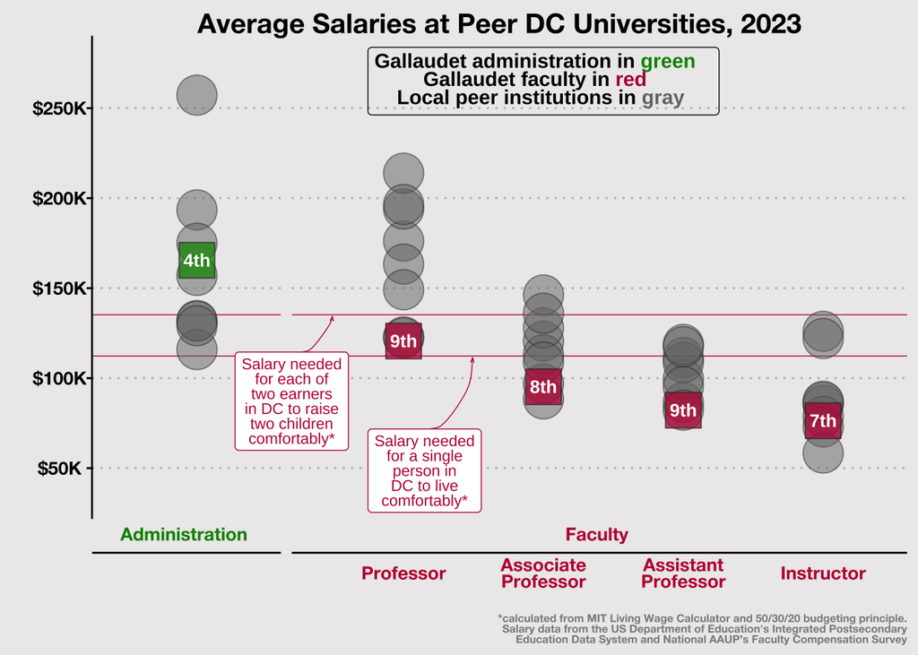

```r
# select if for printing or screen (T is for print, F is for screen only)
for_print <- F
scale_factor <- ifelse(for_print == T, 4, 1)

# fac_admin_colors <- c("#008f00", "#be0b40") # adjust if needed

min_sal_lines <- tibble(
    comf_sal = c(comf_sal_1, comf_sal_2),
    place = c(1.5, 0.5),
    comf_sal_type = c(1, 2),
    label = c(
        str_wrap(comf_sal_1_label, 15),
        str_wrap(comf_sal_2_label, 15)
    ),
    fac_admin = c("fac", "fac")
)

rank_labels = data.frame(
    label = c(
        "4th highest out of 9",
        "9th out of 9",
        "8th out of 9",
        "9th out of 9",
        "7th out of 9"
    ),
    fac_admin = c("admin", rep("fac", 4)),
    job = c("admin", "pr", "ao", "ai", "in"),
    sal = univ_sal$salary
) # For now, put in the labels by hand -- fix up later to automate

facet_labels <- c(admin = "Administration", fac = "Faculty")

color_text <- data.frame(fac_admin = "fac", text = "Gallaudet administration in<span style = 'color:#008f00'> green </span> <br> Gallaudet faculty in<span style = 'color:#b30b40'> red </span> <br>Local peer institutions in<span style = 'color:gray45;'> gray </span>")


sal_local_long |>
    ggplot() +
    geom_hline(yintercept = comf_sal_1,
               linewidth = .25,
               color = aaup_red) +
    geom_hline(yintercept = comf_sal_2,
               linewidth = .25,
               color = aaup_red) +
    geom_point(
        aes(
            x = job_label_color,
            y = salary,
            alpha = univ,
            size = univ,
            color = univ,
            shape = univ,
            fill = fac_admin_other
        )
    ) +
    facet_grid(
        cols = vars(fac_admin),
        switch = "x",
        scales = "free",
        space = "free",
        labeller = labeller(.cols = as_labeller(
            ~ glue::glue("<span style='color: {fac_admin_colors};'> {facet_labels} </span>")
        ))
    ) +

# tweak these parameters

    scale_alpha_manual(values = c(0.75, 0.5)) +
    scale_size_manual(values = c(10, 10)) +
    scale_color_manual(values = c("gray20", "gray20")) +
    # scale_shape_manual(values  = c(15, 16)) +
    scale_shape_manual(values  = c(22, 21)) +
    # scale_color_manual(values = c(aaup_green, aaup_red,"gray45" )) +
    scale_fill_manual(values = c(aaup_green, aaup_red, "gray45")) +

# might need to expand graphic limits

    expand_limits(x = 0.25) +

    labs(
        title = str_wrap("Average Salaries at Peer DC Universities, 2023", 50),
        x = "",
        y = "",

        caption = str_wrap(
            "*calculated from MIT Living Wage Calculator and 50/30/20 budgeting principle. Salary data from the US Department of Education's Integrated Postsecondary Education Data System and National AAUP’s Faculty Compensation Survey",
            80
        )
    ) +

    geom_richtext(
        aes(x = 2, y = 265000, label = text),
        data = color_text,
        size = 3.9 * scale_factor,
        lineheight = 0.3,
        label.color = "black",
        fill = NA,
        fontface = "bold"
    ) +

    theme_aaup_letter_salaries_faceted() +

    scale_y_continuous(
        labels = scales::label_currency(scale_cut = cut_short_scale()),
        limits = c(34000, 278000), # tweak limits
        breaks = seq(50000, 250000, 50000)
    ) +

    coord_cartesian(clip = "off") +

    # lots of tweaks needed to the following
    geom_label_repel(
        aes(x = place  , y = comf_sal, label = label),
        fill = "white",
        data = min_sal_lines,
        size = 3.0 * scale_factor,
       lineheight = ifelse(for_print == T, 0.2, 0.8),
        min.segment.length = 0.0,
        arrow = arrow(angle = 20, length = unit(0.01, "npc")),
        seed = 123,
        label.padding = 0.25,
        color = aaup_red,
        nudge_y = ifelse(min_sal_lines$comf_sal_type == 2, -48000, -65000),
        nudge_x = ifelse(min_sal_lines$comf_sal_type == 1, -0.35, -0.3),
        segment.size = 0.25,
        segment.curvature = 0.7,
        segment.angle = 20,

        xlim = c(-Inf, Inf)
    )  +

    geom_text(
        aes(
            x = job_label_color,
            y = salary,
            label = paste0(rank, "th")
        ),
        data = filter(univ_ranks, fac_admin == "fac") ,
        size = 3.5 * scale_factor,
        color = "white",
        fontface = "bold"
    ) +
    geom_text(
        aes(
            x = job_label_color,
            y = salary,
            label = paste0(rank, "th") # make sure this lazy paste is grammatically correct
        ),
        data = filter(univ_ranks, fac_admin == "admin"),
        color = "white",
        size = 3.5 * scale_factor,
        fontface = "bold"
    )
```

```r
# # uncomment me to save plot
# ggsave("all_faceted.png",
#        dpi = 400,
#        width = 5,
#        height = 5)
```

## Admin only

Create scatterplot for just admin, with extra text box. Might need lots of tweaks.

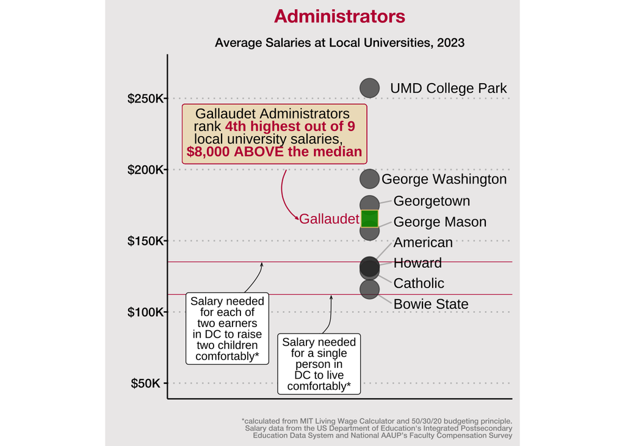

```r
# select if for printing or screen (T is for print, F is for screen only)
for_print <- F
scale_factor <- ifelse(for_print == T, 4, 1)

place_for_boxes <- c(0.99, 0.7) # tweak x-axis values to fit

min_sal_lines <- tibble(
    comf_sal = c(comf_sal_1, comf_sal_2),
    place = place_for_boxes,
    comf_sal_type = c(1, 2),
    label = c(
        str_wrap(comf_sal_1_label, 15),
        str_wrap(comf_sal_2_label, 17) #tweak to fit
    )
)

sal_local_long |>
    filter(job == "admin") |>
  arrange(desc(univ), name) |>
    ggplot() +
    geom_hline(yintercept = comf_sal_1,
               linewidth = .25,
               color = aaup_red) +
    geom_hline(yintercept = comf_sal_2,
               linewidth = .25,
               color = aaup_red) +
    geom_point(aes(
        x = job,
        y = salary,
        alpha = univ,
        size = univ,
        color = univ,
        shape = univ,
        fill = univ
    )) +

    scale_alpha_manual(values = c(0.95, 0.7)) +
    scale_size_manual(values = c(7, 7)) +
    scale_color_manual(values = c(gu_buff, "grey20")) +
    scale_shape_manual(values  = c(22, 21)) +
    scale_fill_manual(values = c(aaup_green, "grey20")) +
    theme_aaup_letter_salaries() +
    theme(axis.text.x = element_blank(), axis.ticks.x = element_blank()) +
    scale_y_continuous(
        labels = scales::label_currency(scale_cut = cut_short_scale()),
        limits = c(50000, 270000),
        breaks = seq(50000, 250000, 50000)
    ) +
    expand_limits(x = .15) +
    labs(
        title = "Administrators",
        subtitle = "Average Salaries at Local Universities, 2023"        ,
        x = "",
        y = "",
        caption = str_wrap(
            "*calculated from MIT Living Wage Calculator and 50/30/20 budgeting principle. Salary data from the US Department of Education's Integrated Postsecondary Education Data System and National AAUP’s Faculty Compensation Survey",
            80
        )
    ) +
    geom_text_repel(
        aes(x = job, y = salary, label = names_short),
        direction = "y",
        hjust = 0,
        box.padding = .3,
        point.padding = 1,
        segment.alpha = 0.25,
        force = 2,
        # seed = 15,
        seed = 17,
        data = filter(sal_local_long, univ != "Gallaudet" &
                          job == "admin"),
        size = 4 * scale_factor,
        nudge_x = 0.1
    )  +
    geom_text_repel(
        aes(x = job, y = salary, label = "Gallaudet"),
        color = aaup_red,
        data = filter(sal_local_long, univ == "Gallaudet", job == "admin"),
        nudge_x = -.17,
        direction = "x",
        point.padding = 5,
        size = 4 * scale_factor
    ) +
    geom_richtext(
        label = "<span style = 'color:black'> Gallaudet Administrators <br> rank </span>**4th highest out of 9**<br> <span style = 'color:black'> local university salaries, </span> <br>**$8,000 ABOVE the median**",
        x = .6,
        y = 225000,
        color = aaup_red,
        fill = bg_mid,
        lineheight = .3,
        size = ifelse(for_print == T, 16, 4)
    )  +

    annotate(
        "curve",
        x = 0.65,
        y = 199900,
        xend = 0.70,
        yend = 165000,
        arrow = arrow(angle = 20, length = unit(0.01, "npc")),
        color = aaup_red,
        angle = 90,
        curvature = .4,
        linewidth = 0.4
    ) +

    geom_label_repel(
        aes(x = place - 0.15 , y = comf_sal),
        label = min_sal_lines$label,
        fill = "white",
        data = min_sal_lines,
        size = 3.25 * scale_factor,
        lineheight = ifelse(for_print == T, 0.2, 0.8),
        min.segment.length = 0.0,
        arrow = arrow(angle = 20, length = unit(0.01, "npc")),
        seed = 123,
        label.padding = 0.25,
        # color = aaup_red,
        color = "black",
        nudge_y = ifelse(min_sal_lines$comf_sal_type == 1, -45000, -53000),
        nudge_x = ifelse(min_sal_lines$comf_sal_type == 1, -0.1, -0.1),
        segment.size = 0.25,
        segment.curvature = ifelse(min_sal_lines$comf_sal_type == 1, 0.7, 0.7),
        segment.angle = ifelse(min_sal_lines$comf_sal_type == 1, 20, 20),
        segment.ncp = 3,
        segment.inflect = FALSE
    )
```

```r
# # uncomment me to save plot
#
# ggsave(
#     "admin_scatter.png",
#     dpi = 400,
#     width = 5,
#     height = 5
# )
```

## Full professors only

Same for full professors only

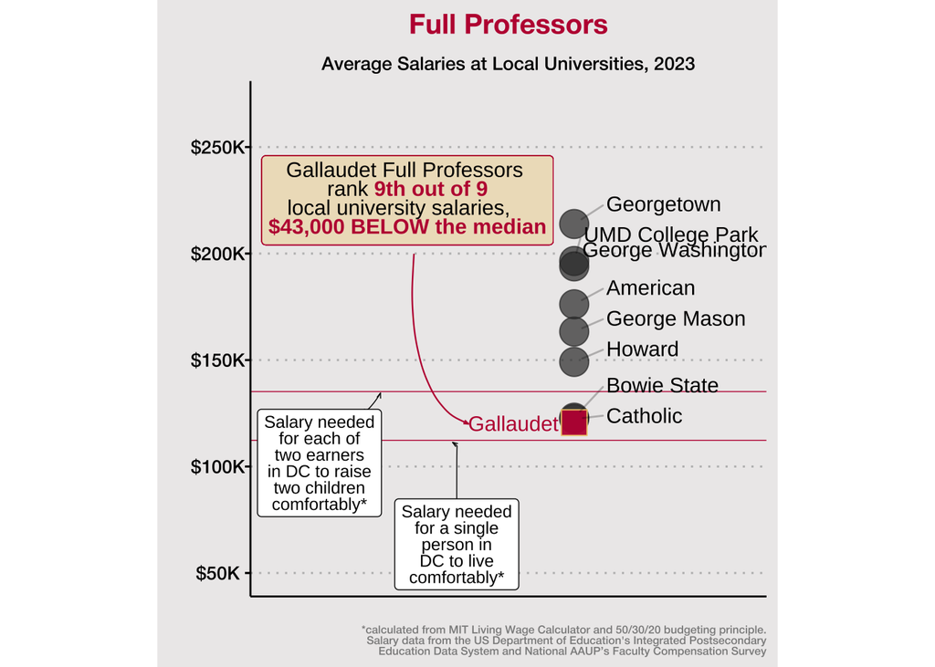

```r
# select if for printing or screen (T is for print, F is for screen only)
for_print <- F
scale_factor <- ifelse(for_print == T, 4, 1)

place_for_boxes <- c(0.92, 0.7) #tweak

min_sal_lines <- tibble(
    comf_sal = c(comf_sal_1, comf_sal_2),
    comf_sal_type = c(1, 2),
    place = place_for_boxes,
 label = c(
        str_wrap(comf_sal_1_label, 15),
        str_wrap(comf_sal_2_label, 17)
))

sal_local_long |>
    filter(job == "pr") |>
    arrange(desc(univ), name) |>
    ggplot() +
    geom_hline(yintercept = 112320,
               linewidth = .25,
               color = aaup_red) +
    geom_hline(yintercept = 135200,
               linewidth = .25,
               color = aaup_red) +
    geom_point(aes(
        x = job,
        y = salary,
        alpha = univ,
        size = univ,
        color = univ,
        shape = univ,
        fill = univ
    )) +

    scale_alpha_manual(values = c(0.95, 0.7)) +
    scale_size_manual(values = c(7, 7)) +
    scale_color_manual(values = c(gu_buff, "grey20")) +
    scale_shape_manual(values  = c(22, 21)) +
    scale_fill_manual(values = c(aaup_red, "grey20")) +
    theme_aaup_letter_salaries() +
    theme(axis.text.x = element_blank(), axis.ticks.x = element_blank()) +
    scale_y_continuous(
        labels = scales::label_currency(scale_cut = cut_short_scale()),
        limits = c(50000, 270000),
        breaks = seq(50000, 250000, 50000)
    ) +

    expand_limits(x = -.01) +
    labs(
        title = "Full Professors",
        subtitle = "Average Salaries at Local Universities, 2023"        ,
        x = "",
        y = "",
        caption = str_wrap(
            "*calculated from MIT Living Wage Calculator and 50/30/20 budgeting principle. Salary data from the US Department of Education's Integrated Postsecondary Education Data System and National AAUP’s Faculty Compensation Survey",
            80
        )

    ) +
    geom_text_repel(
        aes(x = job, y = salary, label = names_short),
        direction = "y",
        box.padding = 0.3,
        point.padding = .5,
        segment.alpha = 0.25,
        force = 1,
        hjust = 0,
        seed = 14,
        data = filter(sal_local_long, univ != "Gallaudet" &
                          job == "pr"),
        size = 4 * scale_factor,
        nudge_x = 0.1,
        nudge_y = 7000,
        xlim = c(1, NA)
    )  +
    geom_text_repel(
        aes(x = job, y = salary, label = "Gallaudet"),
        color = aaup_red,
        data = filter(sal_local_long, univ == "Gallaudet", job == "pr"),
        nudge_x = -.19,
        nudge_y = -500,
        direction = "x",
        point.padding = 5,
        size = 4 * scale_factor,
        lineheight = ifelse(for_print == T, 0.2, 0.8)
    ) +
    geom_richtext(
        #       label = "Gallaudet Full Professors<br> rank **9th out of 9**  \nlocal university salaries,<br>**$43,000 BELOW the median**",
        label = "<span style = 'color:black'> Gallaudet Full Professors <br> rank </span>**9th out of 9**<br> <span style = 'color:black'> local university salaries, </span> <br>**$43,000 BELOW the median**",
        x = .48,
        y = 225000,
        color = aaup_red,
        fill = bg_mid,
        lineheight = 0.3,
        size = ifelse(for_print == T, 16, 4)
    )  +

    annotate(
        "curve",
        x = 0.5,
        y = 199900,
        xend = 0.67,
        yend = 120000,
        arrow = arrow(angle = 20, length = unit(0.01, "npc")),
        color = aaup_red,
        angle = 130,
        curvature = .4,
        linewidth = 0.4
    ) +

    geom_label_repel(
        aes(x = place - 0.3, y = comf_sal),
        label = min_sal_lines$label,
        fill = "white",
        data = min_sal_lines,
        size = 3.25 * scale_factor,
        lineheight = ifelse(for_print == T, 0.2, 0.8),
        min.segment.length = 0.0,
        arrow = arrow(angle = 20, length = unit(0.01, "npc")),
        seed = 123,
        label.padding = 0.25,
        #  color = aaup_red,
        nudge_y = ifelse(min_sal_lines$comf_sal_type == 1, -37000, -51000),
        nudge_x = ifelse(min_sal_lines$comf_sal_type == 1, -0.11, -0.1),
        segment.size = 0.25,
        segment.curvature = ifelse(min_sal_lines$comf_sal_type == 1, 0.7, 0.7),
        segment.angle = ifelse(min_sal_lines$comf_sal_type == 1, 20, 20),
        segment.ncp = 3,
        segment.inflect = FALSE
    )
```

```r
# # uncomment me to save plot
#
# ggsave("prof_scatter.png",
#        dpi = 400,
#        width = 5,
#        height = 5)
```

## Associate professors only

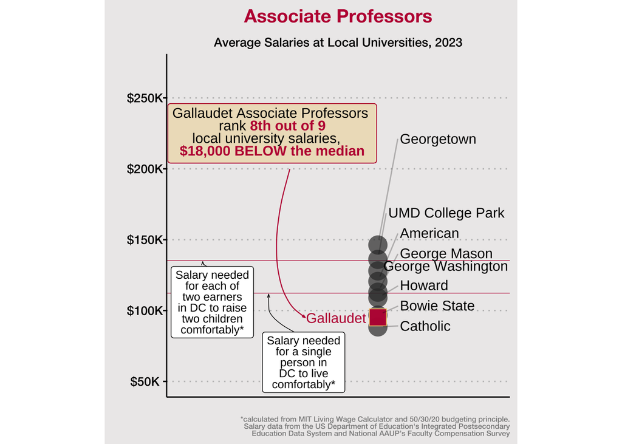

```r
# select if for printing or screen (T is for print, F is for screen only)
for_print <- F
scale_factor <- ifelse(for_print == T, 4, 1)

place_for_boxes <- c(0.5, 0.2) #tweak

min_sal_lines <- tibble(
    comf_sal = c(comf_sal_1, comf_sal_2),
    comf_sal_type = c(1, 2),
    place = place_for_boxes,
 label = c(
        str_wrap(comf_sal_1_label, 15),
        str_wrap(comf_sal_2_label, 17)
))



sal_local_long |>
    filter(job == "ao") |>
    arrange(desc(univ), name) |>
    ggplot() +
    geom_hline(yintercept = 112320,
               linewidth = .25,
               color = aaup_red) +
    geom_hline(yintercept = 135200,
               linewidth = .25,
               color = aaup_red) +
    geom_point(aes(
        x = job,
        y = salary,
        alpha = univ,
        size = univ,
        color = univ,
        shape = univ,
        fill = univ
    )) +

    scale_alpha_manual(values = c(0.95, 0.7)) +
    scale_size_manual(values = c(7, 7)) +
    scale_color_manual(values = c(gu_buff, "grey20")) +
    scale_shape_manual(values  = c(22, 16)) +
    scale_fill_manual(values = c(aaup_red, "grey20")) +
    theme_aaup_letter_salaries() +
    theme(axis.text.x = element_blank(), axis.ticks.x = element_blank()) +
    scale_y_continuous(
        labels = scales::label_currency(scale_cut = cut_short_scale()),
        limits = c(50000, 270000),
        breaks = seq(50000, 250000, 50000)
    ) +

    expand_limits(x = .04) +
    labs(
        title = "Associate Professors",
        subtitle = "Average Salaries at Local Universities, 2023"        ,
        x = "",
        y = "",
        caption = str_wrap(
            "*calculated from MIT Living Wage Calculator and 50/30/20 budgeting principle. Salary data from the US Department of Education's Integrated Postsecondary Education Data System and National AAUP’s Faculty Compensation Survey",
            80
        )
    ) +
    geom_text_repel(
        aes(x = job, y = salary, label = names_short),
        direction = "y",
        box.padding = 0.3,
        point.padding = .5,
        segment.alpha = 0.25,
        force = 1,
        hjust = 0,
        seed = 14,
        data = filter(sal_local_long, univ != "Gallaudet" &
                          job == "ao"),
        size = 4 * scale_factor,
        nudge_x = 0.1,
        nudge_y = 26500,
        xlim = c(1, NA)
    )  +
    geom_text_repel(
        aes(x = job, y = salary, label = "Gallaudet"),
        color = aaup_red,
        data = filter(sal_local_long, univ == "Gallaudet", job == "ao"),
        nudge_x = -.19,
        nudge_y = -500,
        direction = "x",
        point.padding = 5,
        size = 4 * scale_factor
    ) +
    geom_richtext(
        label = "<span style = 'color:black'> Gallaudet Associate Professors <br> rank </span>**8th out of 9**<br> <span style = 'color:black'> local university salaries, </span> <br>**$18,000 BELOW the median**",
        x = .52,
        y = 225000,
        color = aaup_red,
        fill = bg_mid,
        lineheight = .3,
        size = ifelse(for_print == T, 16, 4)
    )  +


    annotate(
        "curve",
        x = 0.6,
        y = 199900,
        xend = 0.67,
        yend = 95000,
        arrow = arrow(angle = 20, length = unit(0.01, "npc")),
        color = aaup_red,
        angle = 130,
        curvature = .4,
        linewidth = 0.4
    ) +

    geom_label_repel(
        aes(x = place , y = comf_sal),
        label = min_sal_lines$label,
        fill = "white",
        data = min_sal_lines,
        size = 3.25 * scale_factor,
        lineheight = ifelse(for_print == T, 0.2, 0.8),
        min.segment.length = 0.0,
        arrow = arrow(angle = 20, length = unit(0.01, "npc")),
        seed = 123,
        label.padding = 0.25,
        #  color = aaup_red,
        nudge_y = ifelse(min_sal_lines$comf_sal_type == 1, -45000, -55000),
        nudge_x = ifelse(min_sal_lines$comf_sal_type == 1, 0, 0),
        segment.size = 0.25,
        segment.curvature = ifelse(min_sal_lines$comf_sal_type == 1, -0.4, -0.4),
        segment.angle = ifelse(min_sal_lines$comf_sal_type == 1, 40, 40),
        segment.ncp = 3,
        segment.inflect = FALSE
    )
```

```r
# # uncomment me to save plot
#
# ggsave(
#     "assoc_scatter.png",
#     dpi = 400,
#     width = 5,
#     height = 5
# )
```

## Assistant profs only

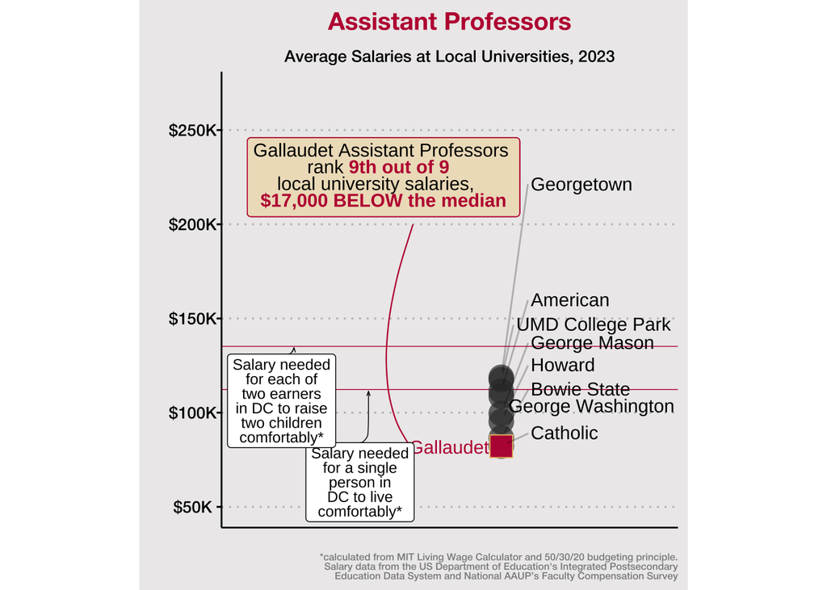

```r
# select if for printing or screen (T is for print, F is for screen only)
for_print <- F
scale_factor <- ifelse(for_print == T, 4, 1)

place_for_boxes <- c(0.55, 0.3) #tweak

min_sal_lines <- tibble(
    comf_sal = c(comf_sal_1, comf_sal_2),
    comf_sal_type = c(1, 2),
    place = place_for_boxes,
 label = c(
        str_wrap(comf_sal_1_label, 15),
        str_wrap(comf_sal_2_label, 17)
))

sal_local_long |>
    filter(job == "ai") |>
    arrange(desc(univ), name) |>
    ggplot() +
    geom_hline(yintercept = 112320,
               linewidth = .25,
               color = aaup_red) +
    geom_hline(yintercept = 135200,
               linewidth = .25,
               color = aaup_red) +
    geom_point(aes(
        x = job,
        y = salary,
        alpha = univ,
        size = univ,
        color = univ,
        shape = univ,
        fill = univ
    )) +

    scale_alpha_manual(values = c(.95, 0.7)) +
    scale_size_manual(values = c(7, 7)) +
    scale_color_manual(values = c(gu_buff, "grey20")) +
    scale_shape_manual(values  = c(22, 16)) +
    scale_fill_manual(values = c(aaup_red, "grey20")) +
    theme_aaup_letter_salaries() +
    theme(axis.text.x = element_blank(), axis.ticks.x = element_blank()) +
    scale_y_continuous(
        labels = scales::label_currency(scale_cut = cut_short_scale()),
        limits = c(50000, 270000),
        breaks = seq(50000, 250000, 50000)
    ) +

    expand_limits(x = 0.05) +
    labs(
        title = "Assistant Professors",
        subtitle = "Average Salaries at Local Universities, 2023"        ,
        x = "",
        y = "",
        caption = str_wrap(
            "*calculated from MIT Living Wage Calculator and 50/30/20 budgeting principle. Salary data from the US Department of Education's Integrated Postsecondary Education Data System and National AAUP’s Faculty Compensation Survey",
            80
        )
    ) +
    geom_text_repel(
        aes(x = job, y = salary, label = names_short),
        direction = "y",
        box.padding = 0.3,
        point.padding = .5,
        segment.alpha = 0.25,
        force = 1,
        hjust = 0,
        seed = 14,
        data = filter(sal_local_long, univ != "Gallaudet" &
                          job == "ai"),
        size = 4 * scale_factor,
        nudge_x = 0.1,
        nudge_y = 30000,
        xlim = c(1, NA)
    )  +
    geom_text_repel(
        aes(x = job, y = salary, label = "Gallaudet"),
        color = aaup_red,
        data = filter(sal_local_long, univ == "Gallaudet", job == "ai"),
        nudge_x = -.17,
        nudge_y = -500,
        direction = "x",
        point.padding = 5,
        size = 4 * scale_factor
    ) +
    geom_richtext(
        label = "<span style = 'color:black'> Gallaudet Assistant Professors <br> rank </span>**9th out of 9** <br> <span style = 'color:black'> local university salaries, </span> <br>**$17,000 BELOW the median**",
        x = .6,
        y = 225000,
        color = aaup_red,
        fill = bg_mid,
        lineheight = .3,
        size = ifelse(for_print == T, 16, 4)
    )  +


    annotate(
        "curve",
        x = 0.7,
        y = 199900,
        xend = 0.69,
        yend = 82000,
        arrow = arrow(angle = 20, length = unit(0.01, "npc")),
        color = aaup_red,
        angle = 130,
        curvature = .3,
        linewidth = 0.4
    ) +

    geom_label_repel(
        aes(x = place , y = comf_sal),
        label = min_sal_lines$label,
        fill = "white",
        data = min_sal_lines,
        size = 3.25 * scale_factor,
        lineheight = ifelse(for_print == T, 0.2, 0.8),
        min.segment.length = 0.0,
        arrow = arrow(angle = 20, length = unit(0.01, "npc")),
        seed = 123,
        label.padding = 0.22,
        # color = aaup_red,
        force = 1,
        nudge_y = ifelse(min_sal_lines$comf_sal_type == 1, -50500, -40000),
        nudge_x = ifelse(min_sal_lines$comf_sal_type == 1, -0.248, 0),
        segment.size = 0.25,
        segment.curvature = ifelse(min_sal_lines$comf_sal_type == 1, 0.4, 0.4),
        segment.angle = ifelse(min_sal_lines$comf_sal_type == 1, 40, 40),
        segment.ncp = 5,
        segment.inflect = FALSE
    )
```

```r
# # uncomment me to save plot
#
# ggsave("asst_scatter.png",
#        dpi = 400,
#        width = 5,
#        height = 5)
```

## Instructors only

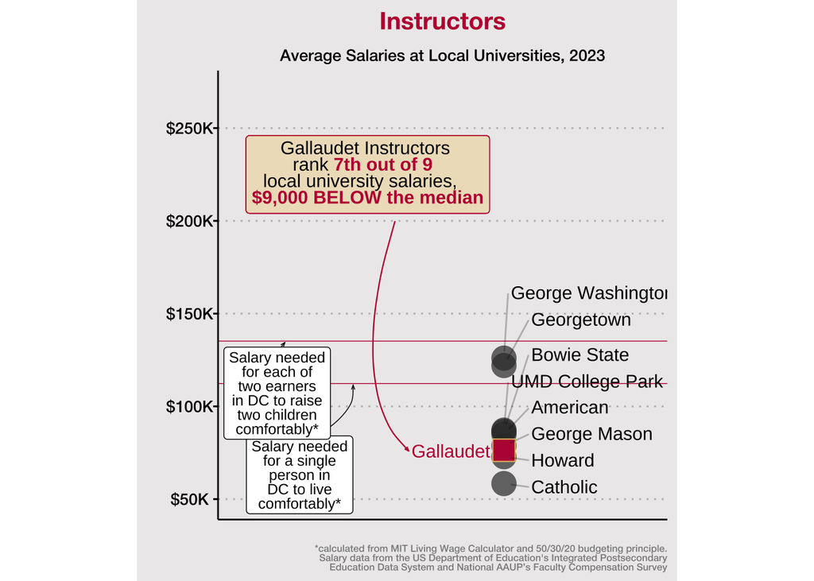

```r
# select if for printing or screen (T is for print, F is for screen only)
for_print <- F
scale_factor <- ifelse(for_print == T, 4, 1)

place_for_boxes <- c(0.45, 0.2) #tweak

min_sal_lines <- tibble(
    comf_sal = c(comf_sal_1, comf_sal_2),
    comf_sal_type = c(1, 2),
    place = place_for_boxes,
 label = c(
        str_wrap(comf_sal_1_label, 15),
        str_wrap(comf_sal_2_label, 17)
))

sal_local_long |>
    filter(job == "in") |>
    arrange(desc(univ), name) |>
    ggplot() +
    geom_hline(yintercept = 112320,
               linewidth = .25,
               color = aaup_red) +
    geom_hline(yintercept = 135200,
               linewidth = .25,
               color = aaup_red) +
    geom_point(aes(
        x = job,
        y = salary,
        alpha = univ,
        size = univ,
        color = univ,
        shape = univ,
        fill = univ
    )) +


    scale_alpha_manual(values = c(0.95, .7)) +
    scale_size_manual(values = c(7, 7)) +
    scale_color_manual(values = c(gu_buff, "grey20")) +
    scale_shape_manual(values  = c(22, 16)) +
    scale_fill_manual(values = c(aaup_red, "grey20")) +
    theme_aaup_letter_salaries() +
    theme(axis.text.x = element_blank(), axis.ticks.x = element_blank()) +
    scale_y_continuous(
        labels = scales::label_currency(scale_cut = cut_short_scale()),
        limits = c(50000, 270000),
        breaks = seq(50000, 250000, 50000)
    ) +

    expand_limits(x = -0.05) +
    labs(
        title = "Instructors",
        subtitle = "Average Salaries at Local Universities, 2023"        ,
        x = "",
        y = "",
        caption = str_wrap(
            "*calculated from MIT Living Wage Calculator and 50/30/20 budgeting principle. Salary data from the US Department of Education's Integrated Postsecondary Education Data System and National AAUP’s Faculty Compensation Survey",
            80
        )
    ) +
    geom_text_repel(
        aes(x = job, y = salary, label = names_short),
        direction = "y",
        box.padding = 0.3,
        point.padding = .5,
        segment.alpha = 0.25,
        force = 1,
        hjust = 0,
        seed = 14,
        data = filter(sal_local_long, univ != "Gallaudet" &
                          job == "in"),
        size = 4 * scale_factor,
        nudge_x = 0.1,
        nudge_y = 30000,
        xlim = c(1, NA)
    )  +
    geom_text_repel(
        aes(x = job, y = salary, label = "Gallaudet"),
        color = aaup_red,
        data = filter(sal_local_long, univ == "Gallaudet", job == "in"),
        nudge_x = -.195,
        nudge_y = -500,
        direction = "x",
        point.padding = 5,
        size = 4 * scale_factor
    ) +
    geom_richtext(
        label = "<span style = 'color:black'> Gallaudet Instructors <br> rank </span>**7th out of 9** <br> <span style = 'color:black'> local university salaries, </span> <br>**$9,000 BELOW the median**",
        x = .5,
        y = 225000,
        color = aaup_red,
        fill = bg_mid,
        lineheight = .3,
        size = ifelse(for_print == T, 16, 4)
    )  +


    annotate(
        "curve",
        x = 0.6,
        y = 199900,
        xend = 0.65,
        yend = 76000,
        arrow = arrow(angle = 20, length = unit(0.01, "npc")),
        color = aaup_red,
        angle = 130,
        curvature = .35,
        linewidth = 0.4
    ) +

    geom_label_repel(
        aes(x = place , y = comf_sal),
        label = min_sal_lines$label,
        fill = "white",
        data = min_sal_lines,
        size = 3.25 * scale_factor,
        lineheight = ifelse(for_print == T, 0.2, 0.8),
        min.segment.length = 0.0,
        arrow = arrow(angle = 20, length = unit(0.01, "npc")),
        seed = 123,
        label.padding = 0.22,
        #  color = aaup_red,
        force = 1,
        nudge_y = ifelse(min_sal_lines$comf_sal_type == 1, -4500, -40000),
        nudge_x = ifelse(min_sal_lines$comf_sal_type == 1, -0.25, 0),
        segment.size = 0.25,
        segment.curvature = ifelse(min_sal_lines$comf_sal_type == 1, 0.2, -0.4),
        segment.angle = ifelse(min_sal_lines$comf_sal_type == 1, 120, 0),
        segment.ncp = 5,
        segment.inflect = FALSE
    )
```

```r
# # uncomment me to save plot
#
# ggsave(
#     "instructor_scatter.png",
#     dpi = 400,
#     width = 5,
#     height = 5
# )
```